# Code Base

- Show All Code
- Hide All Code
- View Source

Author

Andre Thomson

## Approach

For this project, I will use the chess tournament text file from the course. It is not arranged like a normal CSV because each player uses two lines. The first line has the player’s number, name, points, and round results. The second line has the state and pre-rating.

I will read the file into R and find the lines that start with a player number. I will split those lines at the vertical bars and collect the name, points, and opponent numbers. I will use the next line for the state and pre-rating.

Next, I will match each opponent number with that player’s pre-rating and calculate the average. I will leave out byes and unplayed rounds because they do not have an opponent.

## Setup

```r
# tidyverse: data wrangling, parsing, and charts
library(tidyverse)
# stringr: text matching and cleanup
library(stringr)
# knitr: clean HTML table output
library(knitr)
```

## Load the Tournament File

```r
# Look for the tournament file in common project locations first.
# This avoids using a path that only works on one computer.
local_files <- c(
  "tournamentinfo.txt",
  file.path("data", "tournamentinfo.txt"),
  file.path("Project 1", "tournamentinfo.txt")
)

input_file <- local_files[file.exists(local_files)][1]

# Online fallback: public copy of the same DATA 607 tournament dataset.
data_url <- paste0(
  "https://raw.githubusercontent.com/longflin/DATA-607/",
  "refs/heads/main/Project%201/tournamentinfo.txt"
)

if (!is.na(input_file)) {
  raw_lines <- readLines(input_file, warn = FALSE)
  data_source <- input_file
} else {
  raw_lines <- tryCatch(
    readLines(data_url, warn = FALSE),
    error = function(e) {
      stop(
        "Tournament data could not be loaded. ",
        "Put tournamentinfo.txt in the same folder as this QMD ",
        "or in a data/ folder, then render again. ",
        "The online fallback also could not be reached."
      )
    }
  )
  data_source <- data_url
}

cat("Data source:", data_source)
```

```
Data source: https://raw.githubusercontent.com/longflin/DATA-607/refs/heads/main/Project%201/tournamentinfo.txt
```

The code checks for a local copy first. If the file is not there, it tries an online copy of the same tournament dataset. This fixes the original working-directory problem while still allowing the course file to be used when it is available.

## Find the Player Records

```r
# Find lines that begin with a player number followed by a vertical bar
player_line_index <- which(
  str_detect(raw_lines, "^\\s*\\d+\\s*\\|")
)

length(player_line_index)
```

```
[1] 64
```

The first line for each player starts with a player number. I use that pattern to find the player records instead of depending on fixed row numbers.

## Parse the Player Information

```r
# Remove extra spaces around parsed text fields
clean_field <- function(x) {
  str_squish(x)
}

# Pull a 3- or 4-digit chess rating from the rating field
parse_rating <- function(x) {
  rating_match <- str_match(x, "(\\d{3,4})")[, 2]
  as.numeric(rating_match)
}

# Parse every player record and combine the results into one dataframe
players <- map_dfr(player_line_index, function(i) {

  line1 <- str_split(raw_lines[i], "\\|", simplify = TRUE)
  line2 <- str_split(raw_lines[i + 1], "\\|", simplify = TRUE)

  player_no <- as.integer(clean_field(line1[1]))
  player_name <- clean_field(line1[2])
  total_points <- parse_number(clean_field(line1[3]))

  state <- clean_field(line2[1])
  pre_rating <- parse_rating(clean_field(line2[2]))

  round_fields <- if (ncol(line1) >= 4) line1[1, 4:ncol(line1)] else character(0)

  opponent_numbers <- str_match(round_fields, "(\\d+)")[, 2] |>
    as.integer()

  tibble(
    player_no = player_no,
    name = player_name,
    state = state,
    total_points = total_points,
    pre_rating = pre_rating,
    opponent_numbers = list(opponent_numbers)
  )
})
```

This separates the fields from the two-line record and stores each player’s opponent numbers for the next step.

## Check the Parsed Data

```r
dim(players)
```

```
[1] 64  6
```

```r
head(players)
```

```
# A tibble: 6 × 6
  player_no name                state total_points pre_rating opponent_numbers
      <int> <chr>               <chr>        <dbl>      <dbl> <list>
1         1 GARY HUA            ON             6         1544 <int [8]>
2         2 DAKSHESH DARURI     MI             6         1459 <int [8]>
3         3 ADITYA BAJAJ        MI             6         1495 <int [8]>
4         4 PATRICK H SCHILLING MI             5.5       1261 <int [8]>
5         5 HANSHI ZUO          MI             5.5       1460 <int [8]>
6         6 HANSEN SONG         OH             5         1505 <int [8]>
```

```r
sum(is.na(players$name))
```

```
[1] 0
```

```r
sum(is.na(players$pre_rating))
```

```
[1] 0
```

```r
sum(duplicated(players$player_no))
```

```
[1] 0
```

The project description I am using expects 64 players. I also check for missing names, missing ratings, and duplicate player numbers before calculating opponent averages.

```r
stopifnot(nrow(players) == 64)
stopifnot(!anyDuplicated(players$player_no))
```

If one of these checks fails, the code stops instead of silently producing a bad result.

## Calculate Average Opponent Pre-Rating

```r
# Create a lookup table: player number -> pre-rating
rating_lookup <- players |>
  select(player_no, opponent_pre_rating = pre_rating)

# Expand opponent numbers, join opponent ratings, then average by player
final_data <- players |>
  select(
    player_no,
    name,
    state,
    total_points,
    pre_rating,
    opponent_numbers
  ) |>
  unnest_longer(
    opponent_numbers,
    values_to = "opponent_no",
    keep_empty = TRUE
  ) |>
  filter(!is.na(opponent_no)) |>
  left_join(
    rating_lookup,
    by = c("opponent_no" = "player_no")
  ) |>
  group_by(
    player_no,
    name,
    state,
    total_points,
    pre_rating
  ) |>
  summarise(
    average_opponent_pre_rating =
      round(mean(opponent_pre_rating, na.rm = TRUE)),
    .groups = "drop"
  ) |>
  arrange(player_no)
```

Byes and unplayed rounds do not produce an opponent number, so they are left out of the average.

## Final Table

```r
# Keep and rename only the five fields used in the final result
project1_table <- final_data |>
  transmute(
    Name = name,
    State = state,
    `Total Number of Points` = total_points,
    `Pre-Rating` = pre_rating,
    `Average Pre Tournament Chess Rating of Opponents` =
      average_opponent_pre_rating
  )

kable(
  project1_table,
  caption = "Project 1 Chess Tournament Results"
)
```

Project 1 Chess Tournament Results

| Name | State | Total Number of Points | Pre-Rating | Average Pre Tournament Chess Rating of Opponents |
| --- | --- | --- | --- | --- |
| GARY HUA | ON | 6.0 | 1544 | 1233 |
| DAKSHESH DARURI | MI | 6.0 | 1459 | 1266 |
| ADITYA BAJAJ | MI | 6.0 | 1495 | 1417 |
| PATRICK H SCHILLING | MI | 5.5 | 1261 | 1493 |
| HANSHI ZUO | MI | 5.5 | 1460 | 1309 |
| HANSEN SONG | OH | 5.0 | 1505 | 1452 |
| GARY DEE SWATHELL | MI | 5.0 | 1114 | 1475 |
| EZEKIEL HOUGHTON | MI | 5.0 | 1514 | 1377 |
| STEFANO LEE | ON | 5.0 | 1495 | 1323 |
| ANVIT RAO | MI | 5.0 | 1415 | 1351 |
| CAMERON WILLIAM MC LEMAN | MI | 4.5 | 1258 | 1444 |
| KENNETH J TACK | MI | 4.5 | 1268 | 1487 |
| TORRANCE HENRY JR | MI | 4.5 | 1508 | 1410 |
| BRADLEY SHAW | MI | 4.5 | 1013 | 1470 |
| ZACHARY JAMES HOUGHTON | MI | 4.5 | 1561 | 1325 |
| MIKE NIKITIN | MI | 4.0 | 1029 | 1441 |
| RONALD GRZEGORCZYK | MI | 4.0 | 1029 | 1455 |
| DAVID SUNDEEN | MI | 4.0 | 1134 | 1444 |
| DIPANKAR ROY | MI | 4.0 | 1486 | 1409 |
| JASON ZHENG | MI | 4.0 | 1452 | 1466 |
| DINH DANG BUI | ON | 4.0 | 1549 | 1427 |
| EUGENE L MCCLURE | MI | 4.0 | 1240 | 1426 |
| ALAN BUI | ON | 4.0 | 1503 | 1388 |
| MICHAEL R ALDRICH | MI | 4.0 | 1346 | 1383 |
| LOREN SCHWIEBERT | MI | 3.5 | 1248 | 1395 |
| MAX ZHU | ON | 3.5 | 1513 | 1313 |
| GAURAV GIDWANI | MI | 3.5 | 1447 | 1440 |
| SOFIA ADINA STANESCU-BELLU | MI | 3.5 | 1488 | 1397 |
| CHIEDOZIE OKORIE | MI | 3.5 | 1532 | 1487 |
| GEORGE AVERY JONES | ON | 3.5 | 1257 | 1523 |
| RISHI SHETTY | MI | 3.5 | 1513 | 1382 |
| JOSHUA PHILIP MATHEWS | ON | 3.5 | 1407 | 1471 |
| JADE GE | MI | 3.5 | 1469 | 1467 |
| MICHAEL JEFFERY THOMAS | MI | 3.5 | 1505 | 1434 |
| JOSHUA DAVID LEE | MI | 3.5 | 1460 | 1496 |
| SIDDHARTH JHA | MI | 3.5 | 1477 | 1421 |
| AMIYATOSH PWNANANDAM | MI | 3.5 | 1548 | 1498 |
| BRIAN LIU | MI | 3.0 | 1510 | 1369 |
| JOEL R HENDON | MI | 3.0 | 1292 | 1396 |
| FOREST ZHANG | MI | 3.0 | 1489 | 1400 |
| KYLE WILLIAM MURPHY | MI | 3.0 | 1576 | 1309 |
| JARED GE | MI | 3.0 | 1446 | 1465 |
| ROBERT GLEN VASEY | MI | 3.0 | 1410 | 1468 |
| JUSTIN D SCHILLING | MI | 3.0 | 1532 | 1266 |
| DEREK YAN | MI | 3.0 | 1537 | 1489 |
| JACOB ALEXANDER LAVALLEY | MI | 3.0 | 1549 | 1416 |
| ERIC WRIGHT | MI | 2.5 | 1253 | 1413 |
| DANIEL KHAIN | MI | 2.5 | 1436 | 1403 |
| MICHAEL J MARTIN | MI | 2.5 | 1253 | 1488 |
| SHIVAM JHA | MI | 2.5 | 1477 | 1461 |
| TEJAS AYYAGARI | MI | 2.5 | 1520 | 1443 |
| ETHAN GUO | MI | 2.5 | 1491 | 1417 |
| JOSE C YBARRA | MI | 2.0 | 1257 | 1430 |
| LARRY HODGE | MI | 2.0 | 1283 | 1371 |
| ALEX KONG | MI | 2.0 | 1541 | 1442 |
| MARISA RICCI | MI | 2.0 | 1467 | 1438 |
| MICHAEL LU | MI | 2.0 | 1511 | 1379 |
| VIRAJ MOHILE | MI | 2.0 | 1470 | 1474 |
| SEAN M MC CORMICK | MI | 2.0 | 1284 | 1464 |
| JULIA SHEN | MI | 1.5 | 1457 | 1461 |
| JEZZEL FARKAS | ON | 1.5 | 1577 | 1384 |
| ASHWIN BALAJI | MI | 1.0 | 1521 | 1541 |
| THOMAS JOSEPH HOSMER | MI | 1.0 | 1505 | 1419 |
| BEN LI | MI | 1.0 | 1500 | 1363 |

This is the table I will export for the project.

## Quality Checks

```r
nrow(project1_table)
```

```
[1] 64
```

```r
colSums(is.na(project1_table))
```

```
                                            Name
                                               0
                                           State
                                               0
                          Total Number of Points
                                               0
                                      Pre-Rating
                                               0
Average Pre Tournament Chess Rating of Opponents
                                               0
```

```r
sum(duplicated(project1_table$Name))
```

```
[1] 0
```

```r
summary(project1_table)
```

```
        Name          State    Total Number of Points   Pre-Rating
 Length   :64   Length   :64   Min.   :1.000          Min.   :1013
 N.unique :64   N.unique : 3   1st Qu.:2.500          1st Qu.:1290
 N.blank  : 0   N.blank  : 0   Median :3.500          Median :1474
 Min.nchar: 6   Min.nchar: 2   Mean   :3.438          Mean   :1416
 Max.nchar:26   Max.nchar: 2   3rd Qu.:4.000          3rd Qu.:1512
                               Max.   :6.000          Max.   :1577
 Average Pre Tournament Chess Rating of Opponents
 Min.   :1233
 1st Qu.:1384
 Median :1426
 Mean   :1418
 3rd Qu.:1465
 Max.   :1541
```

I use these checks to make sure the final table has the expected number of rows and to catch missing or duplicate values.

### Gary Hua Check

```r
gary_hua_check <- project1_table |>
  filter(str_to_lower(Name) == "gary hua")

gary_hua_check
```

```
# A tibble: 1 × 5
  Name     State `Total Number of Points` `Pre-Rating` Average Pre Tournament …¹
  <chr>    <chr>                    <dbl>        <dbl>                     <dbl>
1 GARY HUA ON                           6         1544                      1233
# ℹ abbreviated name: ¹`Average Pre Tournament Chess Rating of Opponents`
```

## Exploratory Charts

These charts are secondary to the required table. I kept them simple so they help me inspect the cleaned data without taking over the project.

### Pre-Rating Distribution

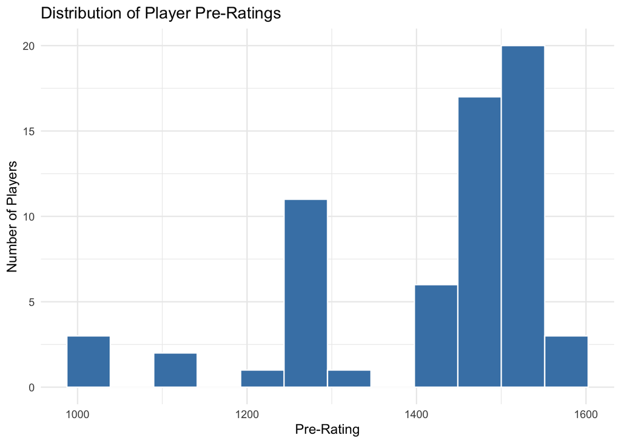

```r
ggplot(project1_table, aes(x = `Pre-Rating`)) +
  geom_histogram(
    bins = 12,
    fill = "steelblue",
    color = "white"
  ) +
  labs(
    title = "Distribution of Player Pre-Ratings",
    x = "Pre-Rating",
    y = "Number of Players"
  ) +
  theme_minimal()
```

The histogram gives a quick view of how the player ratings are distributed.

### Points by Player

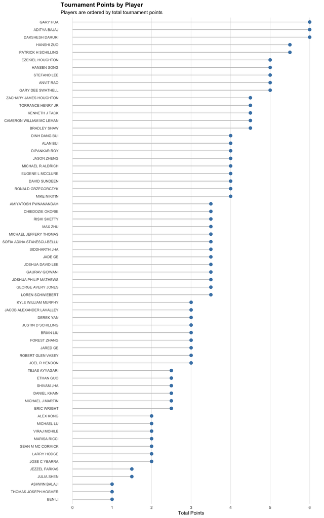

```r
# Order players by points and use pre-rating to break ties.
# The taller figure gives all player names enough room to be readable.
points_plot <- project1_table |>
  arrange(`Total Number of Points`, `Pre-Rating`) |>
  mutate(Name = factor(Name, levels = Name))

ggplot(
  points_plot,
  aes(x = `Total Number of Points`, y = Name)
) +
  geom_segment(
    aes(
      x = 0,
      xend = `Total Number of Points`,
      y = Name,
      yend = Name
    ),
    color = "grey75",
    linewidth = 0.6
  ) +
  geom_point(
    size = 3,
    color = "steelblue"
  ) +
  labs(
    title = "Tournament Points by Player",
    subtitle = "Players are ordered by total tournament points",
    x = "Total Points",
    y = NULL
  ) +
  scale_x_continuous(
    breaks = seq(
      0,
      max(points_plot$`Total Number of Points`, na.rm = TRUE),
      by = 1
    )
  ) +
  theme_minimal(base_size = 11) +
  theme(
    axis.text.y = element_text(size = 8),
    panel.grid.major.y = element_blank(),
    panel.grid.minor = element_blank(),
    plot.title = element_text(face = "bold")
  )
```

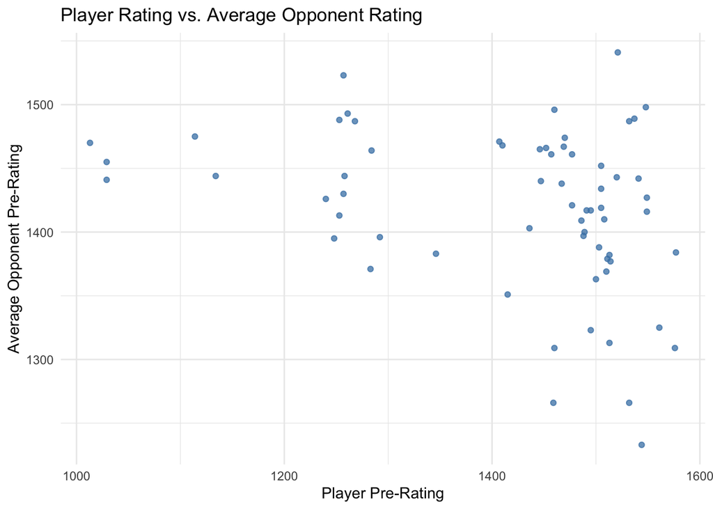

```r
ggplot(
  project1_table,
  aes(
    x = `Pre-Rating`,
    y = `Average Pre Tournament Chess Rating of Opponents`
  )
) +
  geom_point(
    alpha = 0.75,
    color = "steelblue"
  ) +
  labs(
    title = "Player Rating vs. Average Opponent Rating",
    x = "Player Pre-Rating",
    y = "Average Opponent Pre-Rating"
  ) +
  theme_minimal()
```

This scatterplot compares two numeric variables from the final dataset.

## Export the CSV

```r
# Save the final table as a CSV file
write_csv(
  project1_table,
  "project1_chess_results.csv"
)
```

The exported CSV contains only the five requested result columns.

## AI Use

I used GitHub Copilot in Visual Studio Code to help review parts of the R code, troubleshoot errors, and improve code comments. I reviewed the suggestions, kept the code I understood, and checked the results when running the project. The analysis and final results come from the R code and tournament data used in this project.

## References

DATA 607 chess tournament dataset (public copy used only as a fallback):  
https://raw.githubusercontent.com/longflin/DATA-607/refs/heads/main/Project%201/tournamentinfo.txt

Wickham, H., Cetinkaya-Rundel, M., & Grolemund, G. *R for Data Science (2e).*

R Graph Gallery. Lollipop plot examples.

R Graph Gallery. Histogram examples.